# An exploratory data analysis of Pokemon by Eitan Cohen, Raphael Metz, Alexander Sun, and Gautam Rao

Word Count: 1700

Lines of code: 234

### Names & UIDs:

Gautam Rao: 116548939 Eitan Cohen: 116468923 Raphael Metz: 116634595 Alexander Sun: 116685993

#### Introduction

Since the inception of Pokemon, first released for the GameBoy handheld console, there has been a myriad of adaptations and creations related to this virtual world. Some examples include video games, trading cards, television shows, and movies, demonstrating its popularity and fan base. https://bulbapedia.bulbagarden.net/wiki/History_of_Pok%C3%A9mon

Pokemon, originally called “Pocket Monsters”, was created by Satoshi Tajiri. As a child, he would catch insects and tadpoles and wanted to give other children the same thrill in the form of a game. The initial game, Pokemon Red and Green, was released in Japan and allowed players worldwide to trade, catch, and train 151 creatures with the goal to become a Pokemon master. Following this, Media Factory released a Pokemon Trading Card Game, skyrocketing the popularity of Pokemon as a whole. Within the next two years, manga interpretations, anime series, magazines, and even stores were created. The success of Pokemon in Japan lead to it being released worldwide, using the slogan Gotta Catch ‘em All! The Pokemon game is role-playing and turn-based, with each of the Pokemon having a type. When Pokemon Red and Green (or Red and Blue) was released, there were 15 types:

- Normal
- Fire
- Water
- Electric
- Grass
- Ice
- Fighting
- Poison
- Ground
- Flying
- Psychic
- Bug
- Rock
- Ghost
- Dragon

Since then, three types have been added: Dark Steel Fairy

In the world of Pokemon, a Pokemon’s type indicates characteristics and traits that affect the interactions, strategies, and gameplay of each battle. Each type has strengths and weaknesses, having high effectiveness against certain types, but also low effectiveness against others. Here is a brief summary of the strengths and weaknesses of each type:

Normal: Considered to be the most basic type, and having no elemental affinity, this type is not super effective or weak against any other type.

Fire: Has the elemental attribute of fire Strong against Steel, Bug, Ice, and Grass types Weak against Dragon, Rock, and Water types

Water: Associated with the element of water Strong against Ground, Fire, and Rock types Weak against Grass and Electric types

Grass: Associated with plants Strong against Rock, Ground, and Water types Weak against Fire, Flying, Poison, Ice, and Bug types

Electric: Associated with electricity (surprise surprise) Strong against Flying and Water types Weak against Ground types

Ice: Associated with ice/freezing Strong against Dragon, Grass, Ground, and Flying types Weak against Steel, Fighting, Fire, and Rock types

Fighting: Associated with physical fighting (and perhaps martial arts) Strong against Ice, Normal, Dark, Steel, and Rock types Weak against Fairy, Psychic, Flying, and even some other Fighting types

Poison: Associated with venom and toxic abilities Strong against Fairy and Grass types Weak against Psychic, Ground, and other poison types Cannot affect Steel types

Ground: Associated with the earth Strong against Fire, Rock, Steel, Poison, and Electric types Weak against Grass, Ice, and Water types Unaffected by Electric-type attacks

Flying: Able to fly, often birdlike in nature Strong against Fighting, Grass, and Bug types Weak against Ice, Electric, and Rock types

Psychic: Associated with the mind, mental abilities, and psychic powers Strong against Poison and Fighting types Weak against Dark, Bug, and Ghost types

Bug: Associated with arthropods and insects Strong against Psychic, Grass, and Dark types Weak against Flying, Fire, and Rock types

Rock: Associated with being durable Strong against Flying, Fire, and Ice types Weak against Grass, Water, Fighting, Steel, and Ground types

Ghost: Have ghostly or supernatural abilities Strong against Psychic and other Ghost types Weak against Dark and other Ghost types Immune to Fighting and Normal attacks

Dragon: Represent dragons Strong against other Dragon types Weak against Fairy, Ice, and other Dragon types

Dark: Represents the night, darkness, and trickery Strong against Ghost and Psychic types Weak against Fairy, Bug, and Fighting types

Steel: Represent metal and have metallic bodies Strong against Rock, Ice, and Fairy types Weak against Ground, Fire, and Fighting types

Fairy: Associated with being mythical and fairies Strong against Dragon, Dark, and Fighting types Weak against Poison and Steel types Immune to Dragon types

Since there are so many overlapping type strengths and weaknesses we thought we would collect, clean, and display our data based on types.

```python
import requests
import pandas as pd
import bs4
import itertools
import matplotlib.pyplot as plt
import seaborn as sns
from sklearn.linear_model import LinearRegression
from sklearn.model_selection import train_test_split
from sklearn.preprocessing import OneHotEncoder
from sklearn.ensemble import RandomForestClassifier
from sklearn.metrics import accuracy_score
```

### Data Collection:

To collect the data from our project we web scrape information from https:/serebii.net. We use the web scraping tool BeautifulSoup to filter out a table with the class “dextable”. This class contains all pokemon with their abilities and their base stats.

```python
link = 'https://serebii.net/pokemon/nationalpokedex.shtml'

# Get the data from the link
data = requests.get(link).content
bs = bs4.BeautifulSoup(data, 'html.parser')
# Get the table
pokemon_table_raw = bs.find('table', {'class': 'dextable'})
pokemon_table = pd.read_html(str(pokemon_table_raw))[0]
pokemon_table.head(10)
```

|  | 0 | 1 | 2 | 3 | 4 | 5 | 6 | 7 | 8 | 9 | 10 |
| --- | --- | --- | --- | --- | --- | --- | --- | --- | --- | --- | --- |
| 0 | No. | Pic | Name | Type | Abilities | Base Stats | Base Stats | Base Stats | Base Stats | Base Stats | Base Stats |
| 1 | No. | Pic | Name | Type | Abilities | HP | Att | Def | S.Att | S.Def | Spd |
| 2 | #00001 | NaN | Bulbasaur | NaN | Overgrow Chlorophyll | 45 | 49 | 49 | 65 | 65 | 45 |
| 3 | #00002 | NaN | Ivysaur | NaN | Overgrow Chlorophyll | 60 | 62 | 63 | 80 | 80 | 60 |
| 4 | #00003 | NaN | Venusaur | NaN | Overgrow Chlorophyll | 80 | 82 | 83 | 100 | 100 | 80 |
| 5 | #00004 | NaN | Charmander | NaN | Blaze Solar Power | 39 | 52 | 43 | 60 | 50 | 65 |
| 6 | #00005 | NaN | Charmeleon | NaN | Blaze Solar Power | 58 | 64 | 58 | 80 | 65 | 80 |
| 7 | #00006 | NaN | Charizard | NaN | Blaze Solar Power | 78 | 84 | 78 | 109 | 85 | 100 |
| 8 | #00007 | NaN | Squirtle | NaN | Torrent Rain Dish | 44 | 48 | 65 | 50 | 64 | 43 |
| 9 | #00008 | NaN | Wartortle | NaN | Torrent Rain Dish | 59 | 63 | 80 | 65 | 80 | 58 |

As you can see some of the data does not translate well from the read_html function. We need to do more more extraction and cleaning to this data to get everything we need.

```python
pokemon_table.columns = pokemon_table.loc[1]
pokemon_table = pokemon_table.drop([0,1])
pokemon_table.head(10)
```

| 1 | No. | Pic | Name | Type | Abilities | HP | Att | Def | S.Att | S.Def | Spd |
| --- | --- | --- | --- | --- | --- | --- | --- | --- | --- | --- | --- |
| 2 | #00001 | NaN | Bulbasaur | NaN | Overgrow Chlorophyll | 45 | 49 | 49 | 65 | 65 | 45 |
| 3 | #00002 | NaN | Ivysaur | NaN | Overgrow Chlorophyll | 60 | 62 | 63 | 80 | 80 | 60 |
| 4 | #00003 | NaN | Venusaur | NaN | Overgrow Chlorophyll | 80 | 82 | 83 | 100 | 100 | 80 |
| 5 | #00004 | NaN | Charmander | NaN | Blaze Solar Power | 39 | 52 | 43 | 60 | 50 | 65 |
| 6 | #00005 | NaN | Charmeleon | NaN | Blaze Solar Power | 58 | 64 | 58 | 80 | 65 | 80 |
| 7 | #00006 | NaN | Charizard | NaN | Blaze Solar Power | 78 | 84 | 78 | 109 | 85 | 100 |
| 8 | #00007 | NaN | Squirtle | NaN | Torrent Rain Dish | 44 | 48 | 65 | 50 | 64 | 43 |
| 9 | #00008 | NaN | Wartortle | NaN | Torrent Rain Dish | 59 | 63 | 80 | 65 | 80 | 58 |
| 10 | #00009 | NaN | Blastoise | NaN | Torrent Rain Dish | 79 | 83 | 100 | 85 | 105 | 78 |
| 11 | #00010 | NaN | Caterpie | NaN | Shield Dust Run Away | 45 | 30 | 35 | 20 | 20 | 45 |

With the previous information all collected, we can go onto a new website, https://pokemondb.net/pokedex/, and collect various other data. Once we scrape the data, we parse it using BeautifulSoup and filter out information by the table, with the class “vitals-table”. For all Pokemon we extract the primary and secondary types, height in meters, weight in kilograms, catch rate, base happiness, base experience, growth rate, gender variability and egg cycles.

```python
def get_pokemon_data(pokemon_name: str):
    pokemon_name = pokemon_name.replace(' ', '-').replace('♂', '-m').replace('♀', '-f').replace('.','').replace("'", '').replace('é','e').replace(':','')
    link = 'https://pokemondb.net/pokedex/' + pokemon_name.lower() + '/'
    data = requests.get(link).content
    bs = bs4.BeautifulSoup(data, 'html.parser')
    stats_data_raw = bs.findAll('table', {'class': 'vitals-table'})
    stats_data = pd.read_html(str(stats_data_raw))
    types = stats_data[0][1][1].split(' ')
    type = types[0]
    type2 = None
    if len(types) == 2:
        type2 = types[1]
    height = stats_data[0][1][3].split()[0]
    weight = stats_data[0][1][4].split()[0]
    catch_rate = stats_data[1][1][1].split(' ')[0]
    base_happiness = stats_data[1][1][2].split(' ')[0]
    base_exp = stats_data[1][1][3]
    growth_rate = stats_data[1][1][4]
    gender = "Genderless" if stats_data[2][1][1] == "Genderless" else stats_data[2][1][1].split(' ')[0]
    egg_cycles = stats_data[2][1][2].split(' ')[0]
    return {"Name": pokemon_name, "primary_type": type, "secondary_type": type2, "Height": height, "Weight": weight, "catch_rate": catch_rate
            , "base_happiness": base_happiness, "base_exp": base_exp, "growth_rate": growth_rate,
            "gender": gender, "egg_cycles": egg_cycles}

pokemon_data = []
for pokemon in pokemon_table['Name']:
    pokemon_data.append(get_pokemon_data(pokemon))

pokemon_stats = pd.DataFrame(pokemon_data)
pokemon_stats.head(10)
```

|  | Name | primary_type | secondary_type | Height | Weight | catch_rate | base_happiness | base_exp | growth_rate | gender | egg_cycles |
| --- | --- | --- | --- | --- | --- | --- | --- | --- | --- | --- | --- |
| 0 | Bulbasaur | Grass | Poison | 0.7 | 6.9 | 45 | 50 | 64 | Medium Slow | 87.5% | 20 |
| 1 | Ivysaur | Grass | Poison | 1.0 | 13.0 | 45 | 50 | 142 | Medium Slow | 87.5% | 20 |
| 2 | Venusaur | Grass | Poison | 2.0 | 100.0 | 45 | 50 | 236 | Medium Slow | 87.5% | 20 |
| 3 | Charmander | Fire | None | 0.6 | 8.5 | 45 | 50 | 62 | Medium Slow | 87.5% | 20 |
| 4 | Charmeleon | Fire | None | 1.1 | 19.0 | 45 | 50 | 142 | Medium Slow | 87.5% | 20 |
| 5 | Charizard | Fire | Flying | 1.7 | 90.5 | 45 | 50 | 267 | Medium Slow | 87.5% | 20 |
| 6 | Squirtle | Water | None | 0.5 | 9.0 | 45 | 50 | 63 | Medium Slow | 87.5% | 20 |
| 7 | Wartortle | Water | None | 1.0 | 22.5 | 45 | 50 | 142 | Medium Slow | 87.5% | 20 |
| 8 | Blastoise | Water | None | 1.6 | 85.5 | 45 | 50 | 239 | Medium Slow | 87.5% | 20 |
| 9 | Caterpie | Bug | None | 0.3 | 2.9 | 255 | 50 | 39 | Medium Fast | 50% | 15 |

With all the data now collected, we can begin with its processing.

### Data Processing:

We drop the old “Type” column and the “Pic” column, and merge the tables using pd.merge, with an inner merge on the “Name” column. We now have all the information.

```python
pokemon_table = pokemon_table.drop(["Pic", "Type"], axis=1)
full_info = pd.merge(pokemon_table, pokemon_stats, on='Name')
full_info.head(10)
```

|  | No. | Name | Abilities | HP | Att | Def | S.Att | S.Def | Spd | primary_type | secondary_type | Height | Weight | catch_rate | base_happiness | base_exp | growth_rate | gender | egg_cycles |
| --- | --- | --- | --- | --- | --- | --- | --- | --- | --- | --- | --- | --- | --- | --- | --- | --- | --- | --- | --- |
| 0 | #00001 | Bulbasaur | Overgrow Chlorophyll | 45 | 49 | 49 | 65 | 65 | 45 | Grass | Poison | 0.7 | 6.9 | 45 | 50 | 64 | Medium Slow | 87.5% | 20 |
| 1 | #00002 | Ivysaur | Overgrow Chlorophyll | 60 | 62 | 63 | 80 | 80 | 60 | Grass | Poison | 1.0 | 13.0 | 45 | 50 | 142 | Medium Slow | 87.5% | 20 |
| 2 | #00003 | Venusaur | Overgrow Chlorophyll | 80 | 82 | 83 | 100 | 100 | 80 | Grass | Poison | 2.0 | 100.0 | 45 | 50 | 236 | Medium Slow | 87.5% | 20 |
| 3 | #00004 | Charmander | Blaze Solar Power | 39 | 52 | 43 | 60 | 50 | 65 | Fire | None | 0.6 | 8.5 | 45 | 50 | 62 | Medium Slow | 87.5% | 20 |
| 4 | #00005 | Charmeleon | Blaze Solar Power | 58 | 64 | 58 | 80 | 65 | 80 | Fire | None | 1.1 | 19.0 | 45 | 50 | 142 | Medium Slow | 87.5% | 20 |
| 5 | #00006 | Charizard | Blaze Solar Power | 78 | 84 | 78 | 109 | 85 | 100 | Fire | Flying | 1.7 | 90.5 | 45 | 50 | 267 | Medium Slow | 87.5% | 20 |
| 6 | #00007 | Squirtle | Torrent Rain Dish | 44 | 48 | 65 | 50 | 64 | 43 | Water | None | 0.5 | 9.0 | 45 | 50 | 63 | Medium Slow | 87.5% | 20 |
| 7 | #00008 | Wartortle | Torrent Rain Dish | 59 | 63 | 80 | 65 | 80 | 58 | Water | None | 1.0 | 22.5 | 45 | 50 | 142 | Medium Slow | 87.5% | 20 |
| 8 | #00009 | Blastoise | Torrent Rain Dish | 79 | 83 | 100 | 85 | 105 | 78 | Water | None | 1.6 | 85.5 | 45 | 50 | 239 | Medium Slow | 87.5% | 20 |
| 9 | #00010 | Caterpie | Shield Dust Run Away | 45 | 30 | 35 | 20 | 20 | 45 | Bug | None | 0.3 | 2.9 | 255 | 50 | 39 | Medium Fast | 50% | 15 |

We next need to take all columns which are numeric in nature to either ints or floats.

```python
full_info["HP"] = full_info["HP"].astype(int)
full_info["Att"] = full_info["Att"].astype(int)
full_info["Def"] = full_info["Def"].astype(int)
full_info["S.Att"] = full_info["S.Att"].astype(int)
full_info["S.Def"] = full_info["S.Def"].astype(int)
full_info["Spd"] = full_info["Spd"].astype(int)
full_info["Height"] = full_info["Height"].astype(float)
full_info["Weight"] = full_info["Weight"].astype(float)
full_info["catch_rate"] = full_info["catch_rate"].astype(int)
full_info["base_happiness"] = full_info["base_happiness"].astype(int)
full_info["base_exp"] = full_info["base_exp"].astype(int)
full_info["egg_cycles"] = full_info["egg_cycles"].astype(int)
```

We then grab all of the possibilities for abilities in the pokemon world. An ability is a special power that a Pokemon has that affects how it battles. Abilities give Pokemon (or their opponents) new effects, like increasing or decreasing a/all stats, changing the weather or battleground condition, or even protecting it from status conditions. Each species of Pokemon generally has an ability or two which are specific to that species. These abilities are capable of dramatically impacting a Pokemon’s overall performance in battle.

These abilities add extra complexity to pokemon battles. For example, there is an ability called “Levitate” which disallows attacks from any Ground type Pokemon moves.

To obtain the names of these abilities, we once again parse information using BeautifulSoup, from https://pokemondb.net/ability. We get the data with the id “abilities”, and process it further.

```python
abilities_link = "https://pokemondb.net/ability"
data = requests.get(abilities_link).content
bs = bs4.BeautifulSoup(data, 'html.parser')
abilities_table_raw = bs.find('table', {'id': 'abilities'})
abilities_table = pd.read_html(str(abilities_table_raw))[0]
abilities_table.head(10)
```

|  | Name | Pokémon | Description | Gen. |
| --- | --- | --- | --- | --- |
| 0 | Adaptability | 16 | Powers up moves of the same type. | 4 |
| 1 | Aerilate | 2 | Turns Normal-type moves into Flying-type moves. | 6 |
| 2 | Aftermath | 10 | Damages the attacker landing the finishing hit. | 4 |
| 3 | Air Lock | 1 | Eliminates the effects of weather. | 3 |
| 4 | Analytic | 12 | Boosts move power when the Pokémon moves last. | 5 |
| 5 | Anger Point | 12 | Maxes Attack after taking a critical hit. | 4 |
| 6 | Anger Shell | 1 | Lowers Defense/Sp. Def and raises Attack/Sp. A... | 9 |
| 7 | Anticipation | 15 | Senses a foe's dangerous moves. | 4 |
| 8 | Arena Trap | 3 | Prevents the foe from fleeing. | 3 |
| 9 | Armor Tail | 1 | Prevents opponent using priority moves. | 9 |

We take the abilities, and parse it to the original massive table of Pokemon. For example, where the ability used to read “solar power blaze”, it now reads as a list, containing two elements, “Solar Power”, and “Blaze”.

```python
abilities_list = abilities_table["Name"].tolist()
def split_abilities(abilities):
    string_pairs = []
    string_list = abilities.split()
    for combination in list(map(' '.join, itertools.permutations(string_list, 2))):
        if combination in abilities_list:
            string_pairs.append(combination)
    for string in string_list:
        if string in abilities_list:
            string_pairs.append(string)
    #include case for three worded abilities
    for combination in list(map(' '.join, itertools.permutations(string_list, 3))):
        if combination in abilities_list:
            string_pairs.append(combination)
    return string_pairs

#Apply split abilities to the abilities column
full_info["Abilities"] = full_info["Abilities"].apply(split_abilities)
full_info.head(10)
```

|  | No. | Name | Abilities | HP | Att | Def | S.Att | S.Def | Spd | primary_type | secondary_type | Height | Weight | catch_rate | base_happiness | base_exp | growth_rate | gender | egg_cycles |
| --- | --- | --- | --- | --- | --- | --- | --- | --- | --- | --- | --- | --- | --- | --- | --- | --- | --- | --- | --- |
| 0 | #00001 | Bulbasaur | [Overgrow, Chlorophyll] | 45 | 49 | 49 | 65 | 65 | 45 | Grass | Poison | 0.7 | 6.9 | 45 | 50 | 64 | Medium Slow | 87.5% | 20 |
| 1 | #00002 | Ivysaur | [Overgrow, Chlorophyll] | 60 | 62 | 63 | 80 | 80 | 60 | Grass | Poison | 1.0 | 13.0 | 45 | 50 | 142 | Medium Slow | 87.5% | 20 |
| 2 | #00003 | Venusaur | [Overgrow, Chlorophyll] | 80 | 82 | 83 | 100 | 100 | 80 | Grass | Poison | 2.0 | 100.0 | 45 | 50 | 236 | Medium Slow | 87.5% | 20 |
| 3 | #00004 | Charmander | [Solar Power, Blaze] | 39 | 52 | 43 | 60 | 50 | 65 | Fire | None | 0.6 | 8.5 | 45 | 50 | 62 | Medium Slow | 87.5% | 20 |
| 4 | #00005 | Charmeleon | [Solar Power, Blaze] | 58 | 64 | 58 | 80 | 65 | 80 | Fire | None | 1.1 | 19.0 | 45 | 50 | 142 | Medium Slow | 87.5% | 20 |
| 5 | #00006 | Charizard | [Solar Power, Blaze] | 78 | 84 | 78 | 109 | 85 | 100 | Fire | Flying | 1.7 | 90.5 | 45 | 50 | 267 | Medium Slow | 87.5% | 20 |
| 6 | #00007 | Squirtle | [Rain Dish, Torrent] | 44 | 48 | 65 | 50 | 64 | 43 | Water | None | 0.5 | 9.0 | 45 | 50 | 63 | Medium Slow | 87.5% | 20 |
| 7 | #00008 | Wartortle | [Rain Dish, Torrent] | 59 | 63 | 80 | 65 | 80 | 58 | Water | None | 1.0 | 22.5 | 45 | 50 | 142 | Medium Slow | 87.5% | 20 |
| 8 | #00009 | Blastoise | [Rain Dish, Torrent] | 79 | 83 | 100 | 85 | 105 | 78 | Water | None | 1.6 | 85.5 | 45 | 50 | 239 | Medium Slow | 87.5% | 20 |
| 9 | #00010 | Caterpie | [Shield Dust, Run Away] | 45 | 30 | 35 | 20 | 20 | 45 | Bug | None | 0.3 | 2.9 | 255 | 50 | 39 | Medium Fast | 50% | 15 |

We then added the stat “Base Stat” to the list. This stat represents the overall strength of a Pokemon and is obtained by combining all 6 major stats. These stats are HP, Attack, Defense, Special Attack, and Special Defense.

```python
def base_stat():
    base_stat = []
    for index, row in full_info.iterrows():
        base_stat.append(int(row["HP"]) + int(row["Att"]) + int(row["Def"]) + int(row["S.Att"]) + int(row["S.Def"]) + int(row["Spd"]))
    return base_stat

full_info["Base Stat"] = base_stat()

full_info.head(10)
```

|  | No. | Name | Abilities | HP | Att | Def | S.Att | S.Def | Spd | primary_type | secondary_type | Height | Weight | catch_rate | base_happiness | base_exp | growth_rate | gender | egg_cycles | Base Stat |
| --- | --- | --- | --- | --- | --- | --- | --- | --- | --- | --- | --- | --- | --- | --- | --- | --- | --- | --- | --- | --- |
| 0 | #00001 | Bulbasaur | [Overgrow, Chlorophyll] | 45 | 49 | 49 | 65 | 65 | 45 | Grass | Poison | 0.7 | 6.9 | 45 | 50 | 64 | Medium Slow | 87.5% | 20 | 318 |
| 1 | #00002 | Ivysaur | [Overgrow, Chlorophyll] | 60 | 62 | 63 | 80 | 80 | 60 | Grass | Poison | 1.0 | 13.0 | 45 | 50 | 142 | Medium Slow | 87.5% | 20 | 405 |
| 2 | #00003 | Venusaur | [Overgrow, Chlorophyll] | 80 | 82 | 83 | 100 | 100 | 80 | Grass | Poison | 2.0 | 100.0 | 45 | 50 | 236 | Medium Slow | 87.5% | 20 | 525 |
| 3 | #00004 | Charmander | [Solar Power, Blaze] | 39 | 52 | 43 | 60 | 50 | 65 | Fire | None | 0.6 | 8.5 | 45 | 50 | 62 | Medium Slow | 87.5% | 20 | 309 |
| 4 | #00005 | Charmeleon | [Solar Power, Blaze] | 58 | 64 | 58 | 80 | 65 | 80 | Fire | None | 1.1 | 19.0 | 45 | 50 | 142 | Medium Slow | 87.5% | 20 | 405 |
| 5 | #00006 | Charizard | [Solar Power, Blaze] | 78 | 84 | 78 | 109 | 85 | 100 | Fire | Flying | 1.7 | 90.5 | 45 | 50 | 267 | Medium Slow | 87.5% | 20 | 534 |
| 6 | #00007 | Squirtle | [Rain Dish, Torrent] | 44 | 48 | 65 | 50 | 64 | 43 | Water | None | 0.5 | 9.0 | 45 | 50 | 63 | Medium Slow | 87.5% | 20 | 314 |
| 7 | #00008 | Wartortle | [Rain Dish, Torrent] | 59 | 63 | 80 | 65 | 80 | 58 | Water | None | 1.0 | 22.5 | 45 | 50 | 142 | Medium Slow | 87.5% | 20 | 405 |
| 8 | #00009 | Blastoise | [Rain Dish, Torrent] | 79 | 83 | 100 | 85 | 105 | 78 | Water | None | 1.6 | 85.5 | 45 | 50 | 239 | Medium Slow | 87.5% | 20 | 530 |
| 9 | #00010 | Caterpie | [Shield Dust, Run Away] | 45 | 30 | 35 | 20 | 20 | 45 | Bug | None | 0.3 | 2.9 | 255 | 50 | 39 | Medium Fast | 50% | 15 | 195 |

Now all of the data is organized, and ready for further analysis.

### Data Visualisation:

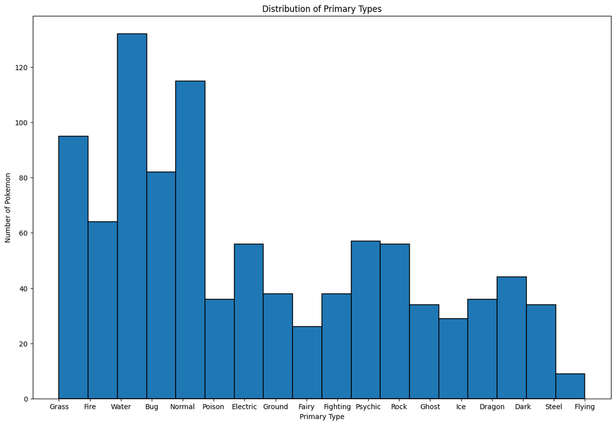

```python
#bar graph showing distribution of primary types
plt.figure(figsize=(15,10))
plt.title("Distribution of Primary Types")
plt.xlabel("Primary Type")
plt.ylabel("Number of Pokemon")
plt.hist(full_info["primary_type"], edgecolor='black', linewidth=1.2, bins=18)
plt.show()
```

The first graph we have here is distribution of primary types. Obviously, the water type has the most species of Pokemon, with close to 130 unique species. Next are normal type, with just under 120, and grass with just under 100. The type with the least is Flying, with around 10. This is because many flying type pokemon have flying as a secondary type, while not being their primary type. For example, the species “Pidgeot" is Normal/Flying.

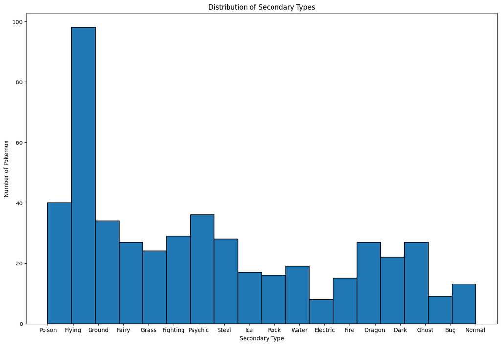

```python
plt.figure(figsize=(15,10))
plt.title("Distribution of Secondary Types")
plt.xlabel("Secondary Type")
plt.ylabel("Number of Pokemon")
del_none = full_info.copy(deep=True)
del_none = del_none.mask(del_none["secondary_type"].eq('None')).dropna()
plt.hist(del_none["secondary_type"], edgecolor='black', linewidth=1.2, bins=18)
plt.show()
```

Now when discussing secondary types there’s a very opposite trend. Flying type has the most, with just shy of 100 species. This is to be expected as most flying types are not considered pure flying types. Electric type has the least, with less than 10 species using it as a secondary type.

The next series of plots are violin graphs, which display the distribution of primary type and base states.

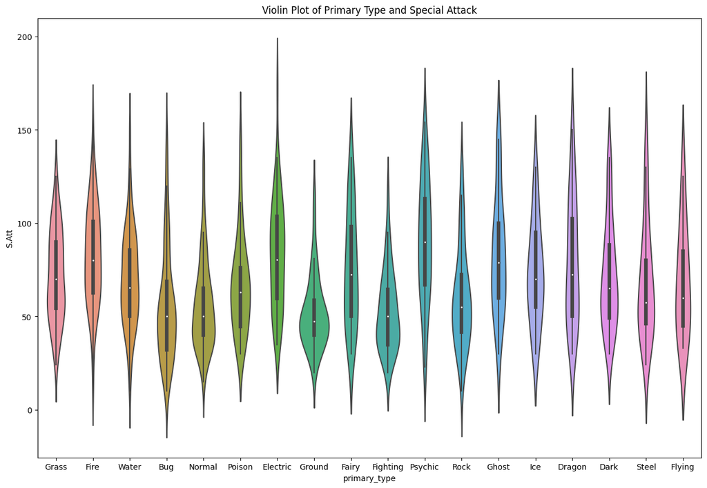

```python
#Show a violin plot of type and special attack
plt.figure(figsize=(15,10))
sns.violinplot(x="primary_type", y="S.Att", data=full_info)
plt.title("Violin Plot of Primary Type and Special Attack")
plt.show()
```

The first is primary type and special attack. Although there is one electric type pokemon which has an insanely high special attack, the type with the highest median is psychic. Electric type follows as a close second. This makes sense, as the type psychic so aptly implies.

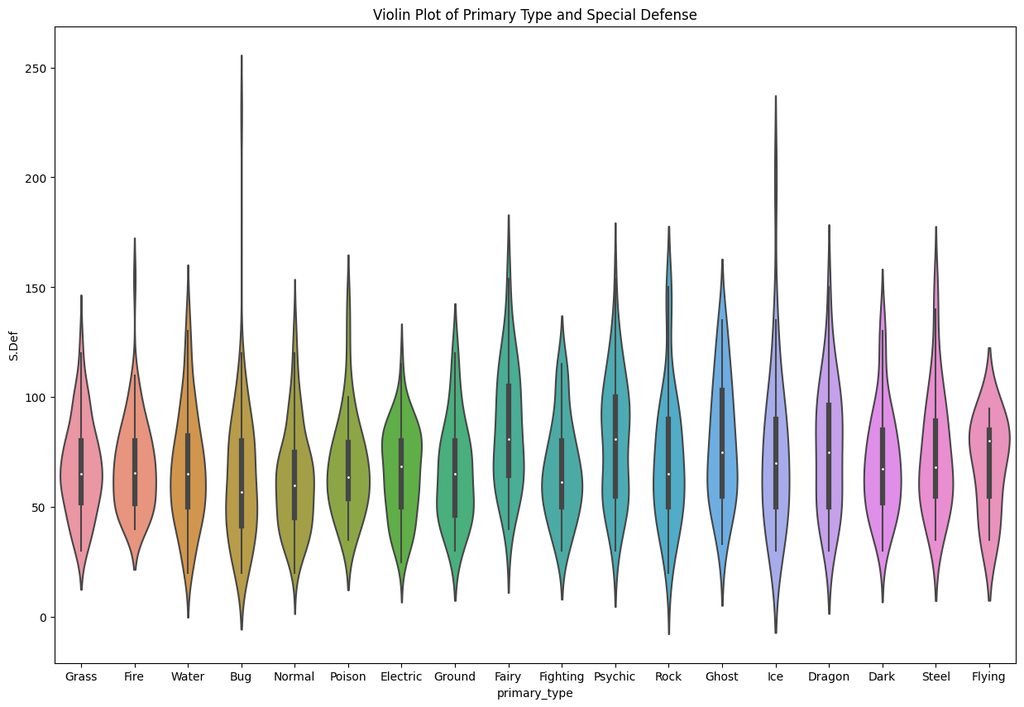

```python
plt.figure(figsize=(15,10))
sns.violinplot(x="primary_type", y="S.Def", data=full_info)
plt.title("Violin Plot of Primary Type and Special Defense")
plt.show()
```

The next is primary type and special defense. The highest median special defense is a tie between fairy and psychic types, although the pokemon with the highest special defense is a bug type pokemon.

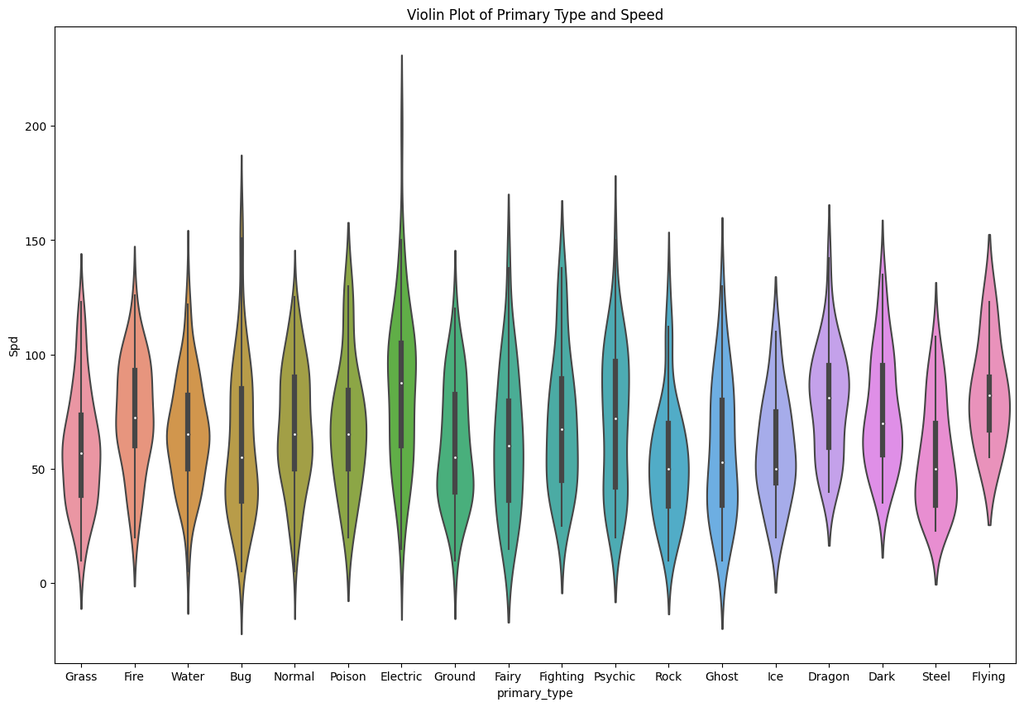

```python
plt.figure(figsize=(15,10))
sns.violinplot(x="primary_type", y="Spd", data=full_info)
plt.title("Violin Plot of Primary Type and Speed")
plt.show()
```

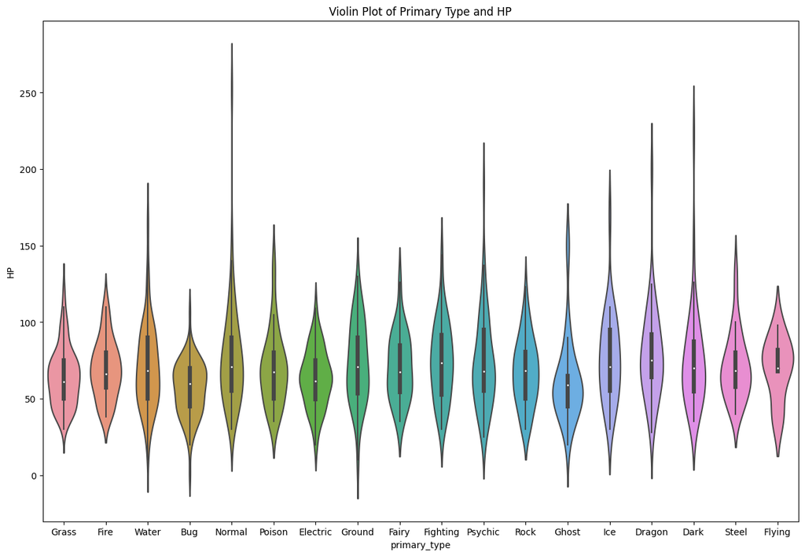

```python
plt.figure(figsize=(15,10))
sns.violinplot(x="primary_type", y="HP", data=full_info)
plt.title("Violin Plot of Primary Type and HP")
plt.show()
```

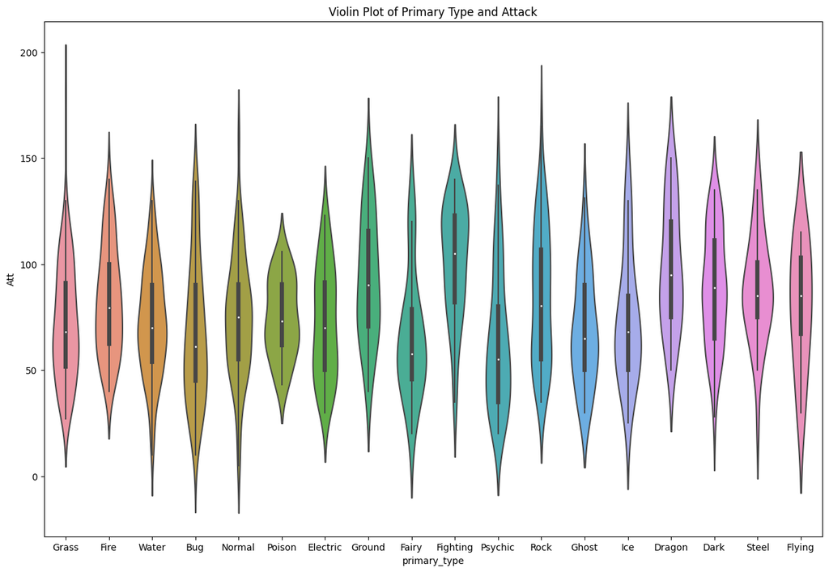

```python
plt.figure(figsize=(15,10))
sns.violinplot(x="primary_type", y="Att", data=full_info)
plt.title("Violin Plot of Primary Type and Attack")
plt.show()
```

The next is primary type and attack. This one is all over the place. Aptly, fighting has a very high median attack, although a grass type has the highest overall. The lowest median is psychic, which one again makes sense.

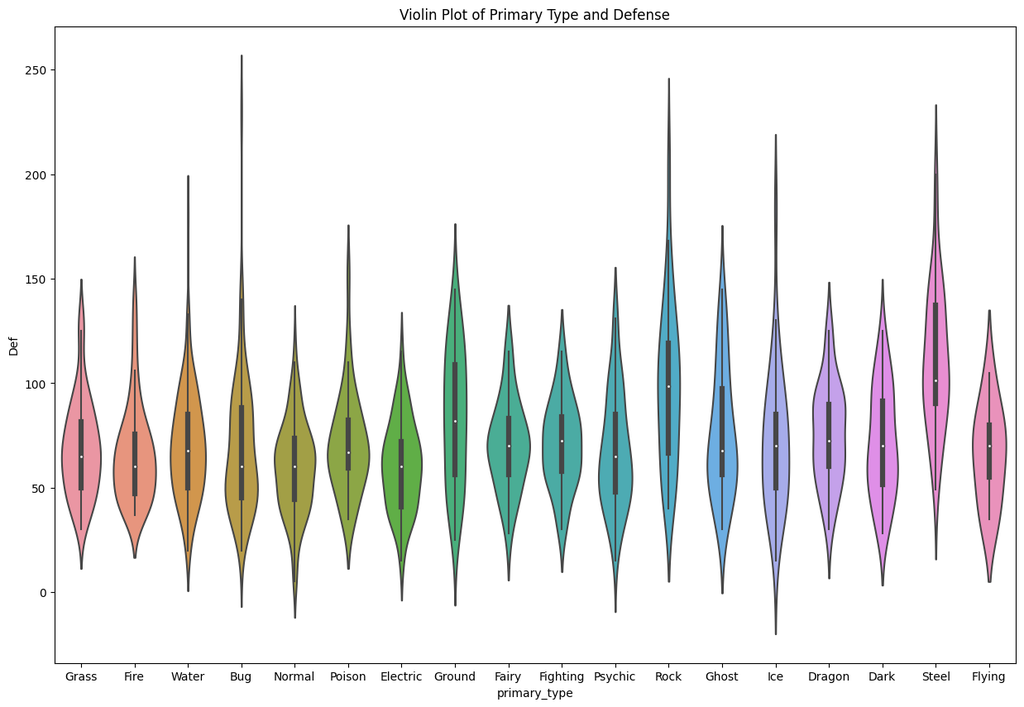

```python
plt.figure(figsize=(15,10))
sns.violinplot(x="primary_type", y="Def", data=full_info)
plt.title("Violin Plot of Primary Type and Defense")
plt.show()
```

We next graph against the base stat, with height/weight, We find a line of regression for the weight/height and base state, and then show scatter plots with the linear regression lines.

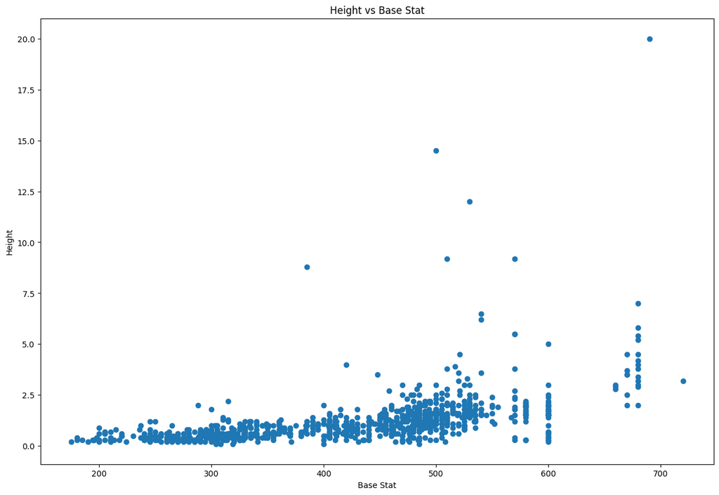

```python
# Show a violin plot of Height and base stat
plt.figure(figsize=(15,10))
plt.scatter(full_info["Base Stat"],full_info["Height"])
plt.title("Height vs Base Stat")
plt.xlabel("Base Stat")
plt.ylabel("Height")
plt.show()
```

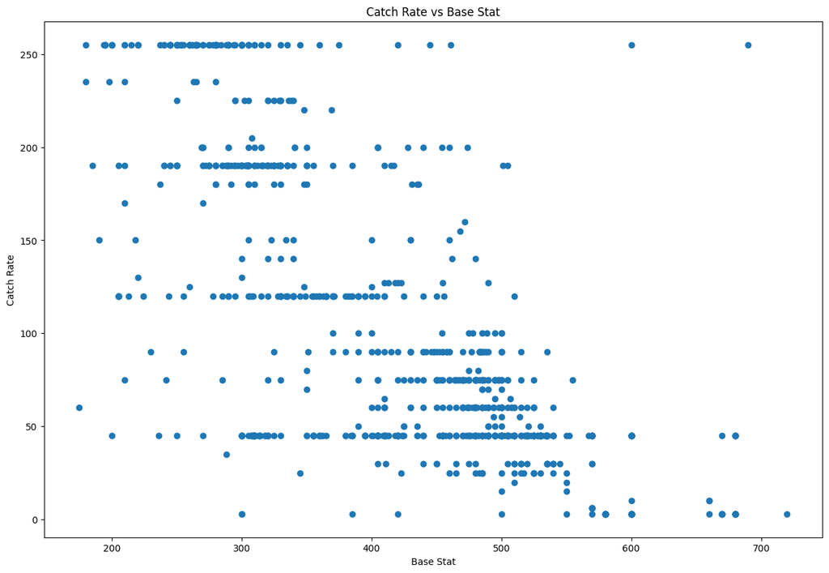

```python
#Create a scatter plot with base stat and catch rate
plt.figure(figsize=(15,10))
plt.scatter(full_info["Base Stat"],full_info["catch_rate"])
plt.title("Catch Rate vs Base Stat")
plt.xlabel("Base Stat")
plt.ylabel("Catch Rate")
plt.show()
```

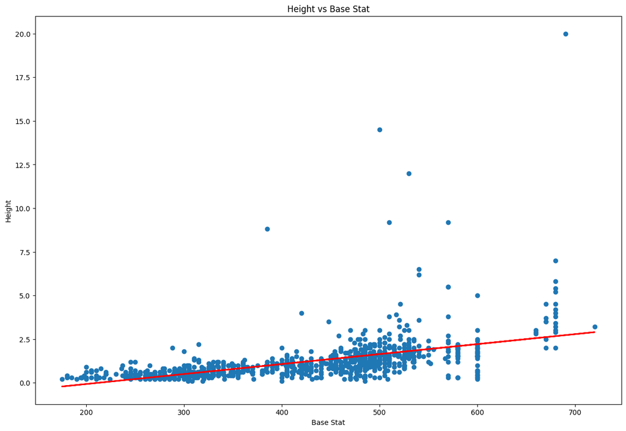

```python
#Find linear regression line for weight and base stat
x = full_info["Base Stat"]
y = full_info["Height"]
reg_height = LinearRegression().fit(x.values.reshape(-1,1), y.values.reshape(-1,1))

#Show scatter plot with linear regression line
plt.figure(figsize=(15,10))
plt.scatter(x, y)
plt.plot(x, reg_height.predict(x.values.reshape(-1,1)), color='red', linewidth=2)
plt.title("Height vs Base Stat")
plt.xlabel("Base Stat")
plt.ylabel("Height")
plt.show()
```

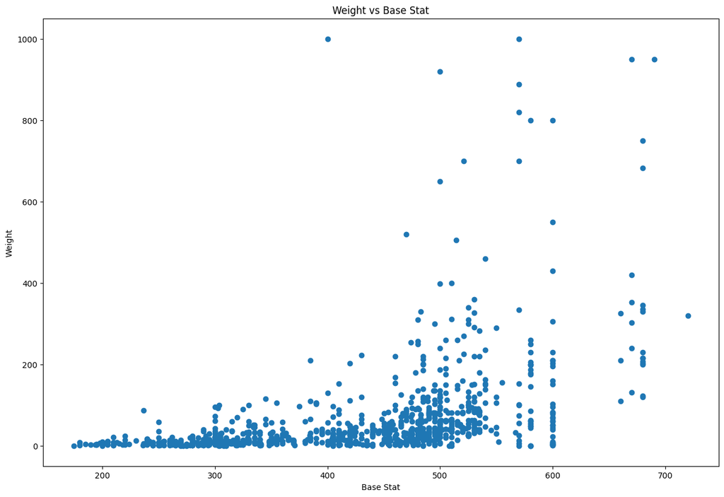

```python
#Show a scatter plot of weight and base stat
plt.figure(figsize=(15,10))
plt.scatter(full_info["Base Stat"], full_info["Weight"])
plt.title("Weight vs Base Stat")
plt.xlabel("Base Stat")
plt.ylabel("Weight")
plt.show()
```

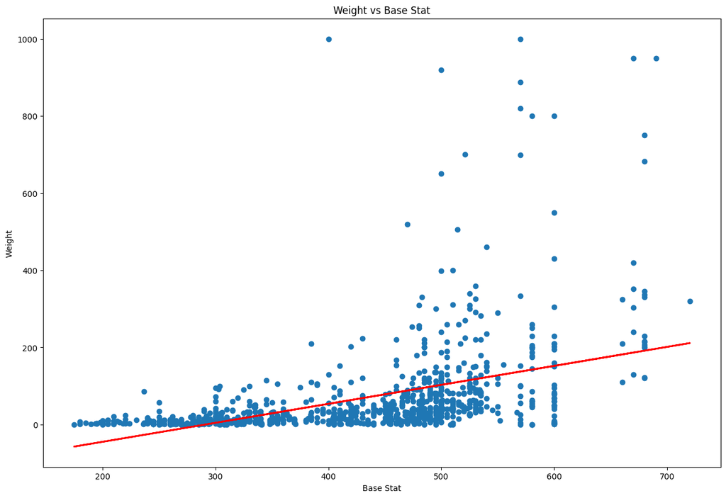

```python
#Find linear regression line for weight and base stat
x = full_info["Base Stat"]
y = full_info["Weight"]
reg_weight = LinearRegression().fit(x.values.reshape(-1,1), y.values.reshape(-1,1))

#Show scatter plot with linear regression line
plt.figure(figsize=(15,10))
plt.scatter(x, y)
plt.plot(x, reg_weight.predict(x.values.reshape(-1,1)), color='red', linewidth=2)
plt.title("Weight vs Base Stat")
plt.xlabel("Base Stat")
plt.ylabel("Weight")
plt.show()
```

```python
print(str(reg_height.coef_[0][0]) + " " +  str(reg_height.intercept_[0]))
print(str(reg_weight.coef_[0][0]) + " " + str(reg_weight.intercept_[0]))
```

```
0.005714520125944164 -1.2179323453428506
0.49245743182148916 -143.20638893194402
```

As you can see there seems to be a slight correlation between both height and weight and base stat, moreso with weight.

Which type is the strongest overall? Which is the weakest?

How would we define "strongest" and "weakest"? Let's use the average base stat of each type to determine this.

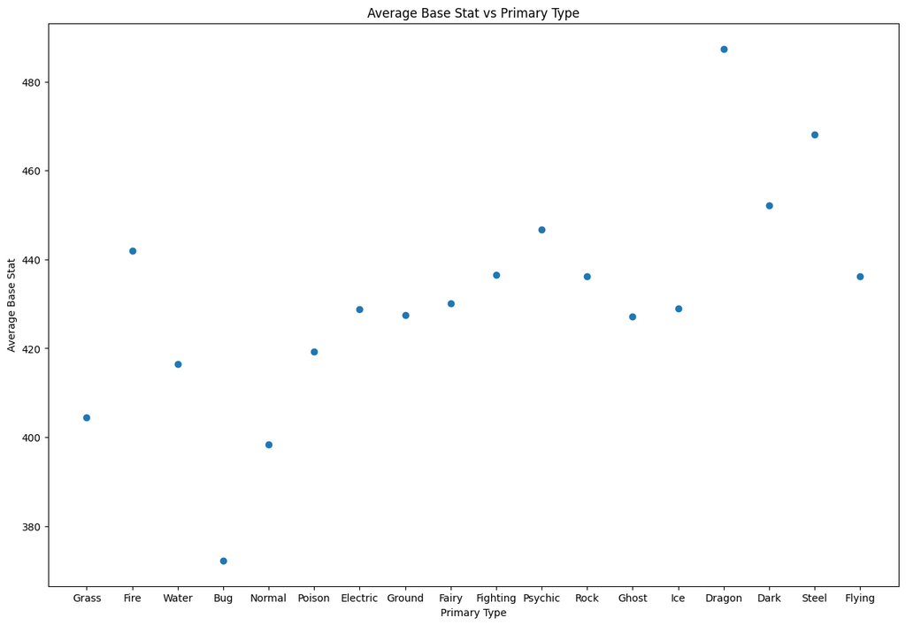

```python
primary_type = full_info["primary_type"].unique()
average_base_stat = []
for type in primary_type:
    average_base_stat.append(full_info[full_info["primary_type"] == type]["Base Stat"].mean())

#Show scatter plot of primary type and average base stat
plt.figure(figsize=(15,10))
plt.scatter(primary_type, average_base_stat)
plt.title("Average Base Stat vs Primary Type")
plt.xlabel("Primary Type")
plt.ylabel("Average Base Stat")
plt.show()
```

We next try to find the strongest and weakest overall pokemon type. We do this by finding the average base stats of each type, and then graph it on a scatter plot. Dragon type has the highest, and the lowest belongs to bug type.

Next we attempt to create a machine learning algorithm which takes in a pokemon’s base stat, catch rate, happiness, experience, height and weight. We use a RandomForestClassifier from sklearn, and fit the model with a training set. We predict it on a test set and get an accuracy of about 25%. We test a few pokemon to guess their type and get a fair amount right. Unfortunately the model isn’t 100% accurate.

```python
# Here we copy the dataframe with all of the data and manipulate so we can create a model to classify Pokemon types
df = full_info.copy(deep=True)
df.drop(['Abilities','gender', 'growth_rate', 'secondary_type', 'No.'], inplace=True, axis=1)

X = df.drop(['Name','primary_type'], axis=1)
Y = df['primary_type']
X_encoded = pd.get_dummies(X)
X_train, X_test, y_train, y_test = train_test_split(X_encoded, Y, test_size=0.2, random_state=42)
selected_features = ['HP', 'Att', 'Def', 'S.Att', 'S.Def', 'Spd', 'Height', 'Weight', 'catch_rate', 'base_happiness', 'base_exp']
model = RandomForestClassifier(n_estimators=100, random_state=42)
model.fit(X_train[selected_features], y_train)
y_pred = model.predict(X_test[selected_features])
accuracy = accuracy_score(y_test, y_pred)
print(f"Accuracy: {accuracy}")
```

```
Accuracy: 0.2436548223350254
```

```python
# Function to test our model on any Pokemon
def test_pokemon_type(name):
    test_pokemon = full_info[full_info['Name'] == name]
    test_pokemon.drop(['Name', 'Abilities','gender', 'growth_rate', 'secondary_type', 'No.', 'primary_type', 'Base Stat', 'secondary_type', 'egg_cycles'], inplace=True, axis=1)
    prediction = model.predict(test_pokemon)
    print("The type prediction for ", name, " is ", prediction)
```

```python
test_pokemon_type("Charizard")
test_pokemon_type("Pikachu")
test_pokemon_type("Piplup")
test_pokemon_type("Dialga")
test_pokemon_type("Caterpie")
test_pokemon_type("Wartortle")
test_pokemon_type("Palkia")
test_pokemon_type("Exeggcute")
#All of these are correct types
```

[output not shown]

[output not shown]

```python
test_pokemon_type("Magearna")
test_pokemon_type("Lotad")
```

```
The type prediction for  Magearna  is  ['Dark']
The type prediction for  Lotad  is  ['Grass']
```

These are not correct types.